# G4016 Lab 3

Jonathan Kuek

4 December 2015

The independent variables here are age, real respondent income, trust and highest educational achievement. I have recoded trust to be a binary variable where 1 is “most people can be trusted” and 0 is everything else. Also, I have recoded degree to show 1 if the respondent has a degree or higher and 0 otherwise.

[output not shown]

#### 1. Create a multivariate time series; perform any interpolations.

```r
data <- read.csv("~/Desktop/Columbia Fall Courses/G4016 Temporal Process/Lab/Lab 3/trends-gss.csv")

vars <- c("year", "fair", "degree", "wrkstat", "age", "realrinc", "sex", "trust")
sub <- data[, vars]

#Recoding
sub <- mutate(sub,
              fair = ifelse(fair == 2, 1, 0),
              degree = ifelse(degree >= 3, 1, 0),
              trust = ifelse(trust == 1, 1, 0),
              )

# get means by year
by.year <- aggregate(subset(sub, sel = -year), list(year = sub$year), mean, na.rm = T)

# interpolate for some missing years
# add the extra years
by.year[30:40, "year"] <- c(1979, 1981, 1992, 1995, seq(1997, 2009, 2))
by.year <- arrange(by.year, year)

# make a time series object by.year.ts and interpolate using na.approx
by.year.ts <- ts(by.year)
by.year.ts <- na.approx(by.year.ts)

by.year.ts <- as.data.frame(by.year.ts)
by.year.ts <- mutate(by.year.ts,
                     fair_pct = fair*100,
                     trust_pct = trust*100,
                     degree_pct = degree*100)

# correlations
cor.vars <- c("fair_pct", "degree_pct", "realrinc", "age", "trust_pct")
cor.dat <- by.year.ts[, cor.vars]
cor(cor.dat, use = "complete")
```

```
##              fair_pct degree_pct   realrinc        age  trust_pct
## fair_pct    1.0000000 -0.8945212 -0.6314437 -0.6863236  0.8138464
## degree_pct -0.8945212  1.0000000  0.6572283  0.8232543 -0.8404146
## realrinc   -0.6314437  0.6572283  1.0000000  0.6999333 -0.5341838
## age        -0.6863236  0.8232543  0.6999333  1.0000000 -0.7137159
## trust_pct   0.8138464 -0.8404146 -0.5341838 -0.7137159  1.0000000
```

Looking at the correlation table, I would infer that other than trust the other three independent variables all have negative correlation with fair. The absolute value of the correlation coefficient for all four independent variables are above 0.6. The highest being close to 0.9.

#### 2. Graph the relationships between X and Y. Explain how you think Y should relate to your key Xs.

My expectations of the relationship between the dependent variables and independent variables is similar to the direction of their correlation. I would expect trust and fair to be positively related, as trust goes up, you are more likely to believe that people would be fair, all else equals.

I would expect that as age increase, the less you are would believe that people be fair because you would have seen your fair share of people taking advantage of others.

I would also expect that the more education you recieved, the less you would believe that people would be fair because school is also competitive in a way.

Lastly, the higher your income, the less you would believe that people would be fair because a higher paying job may indicate a more competitive work environment where fairness is less often seen.

```r
keep.vars <- c("year", "fair_pct", "degree_pct", "realrinc", "trust_pct", "age")

# Use meltMyTS to transform the data to a 3-column dataset containing a column
# for time, a column for variable names, and a column of values corresponding to
# the variable names

plot.dat <- meltMyTS(mv.ts.object = by.year.ts, time.var = "year", keep.vars = keep.vars)
plot.dat
```

```
##     time   variable       value
## 1   1972   fair_pct    59.92462
## 2   1973   fair_pct    57.59197
## 3   1974   fair_pct    59.85967
## 4   1975   fair_pct    62.12737
## 5   1976   fair_pct    59.49027
## 6   1977   fair_pct    62.18738
## 7   1978   fair_pct    64.88449
## 8   1979   fair_pct    62.85604
## 9   1980   fair_pct    60.82759
## 10  1981   fair_pct    60.53069
## 11  1982   fair_pct    60.23380
## 12  1983   fair_pct    59.93691
## 13  1984   fair_pct    62.23586
## 14  1985   fair_pct    62.40227
```

[output cut: 186 more lines]

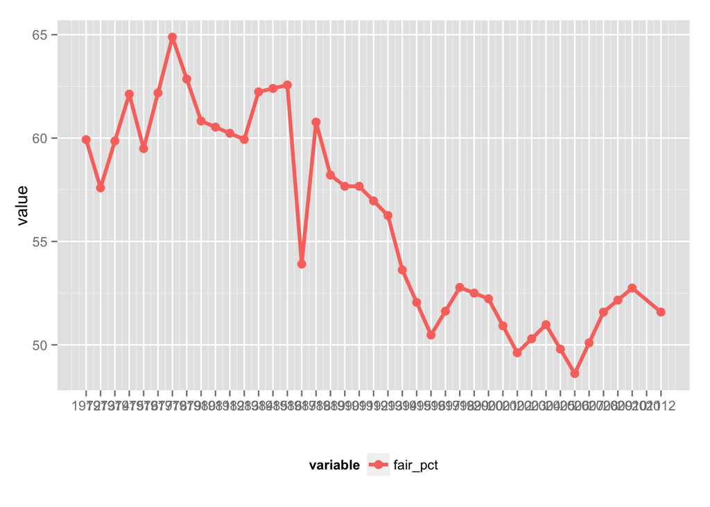

```r
# Use ggMyTS to plot dependent variable and the combination of dependent variable with individual variables
(g_fair_pct <- ggMyTS(df = plot.dat, varlist = c("fair_pct")))
```

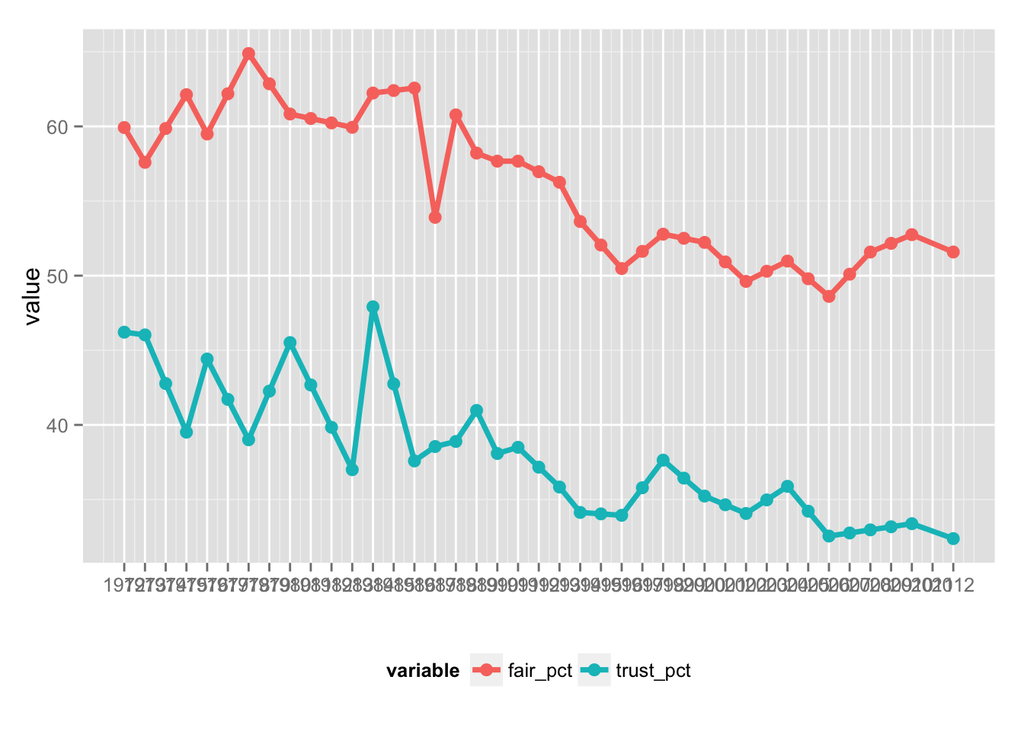

```r
(g_trust_pct <- ggMyTS(df = plot.dat, varlist = c("fair_pct", "trust_pct")))
```

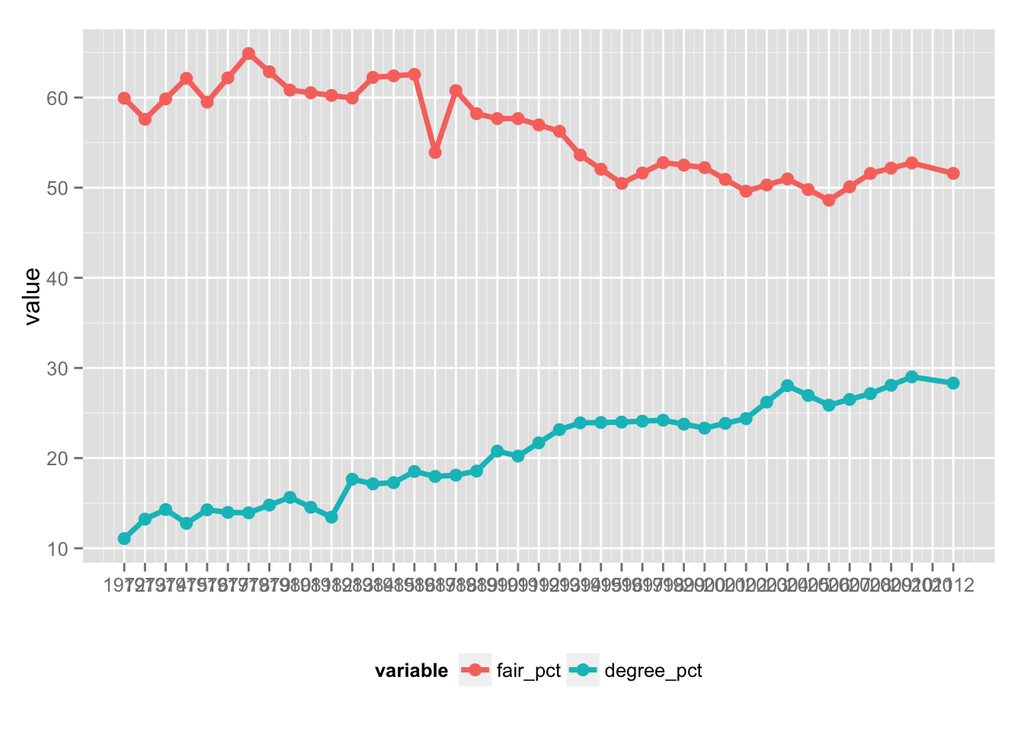

```r
(g_degreelt50_pct <- ggMyTS(df = plot.dat, varlist = c("fair_pct", "degree_pct")))
```

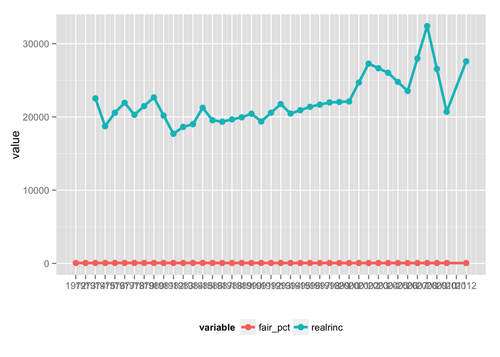

```r
(g_income <- ggMyTS(df = plot.dat, varlist = c("fair_pct", "realrinc")))
```

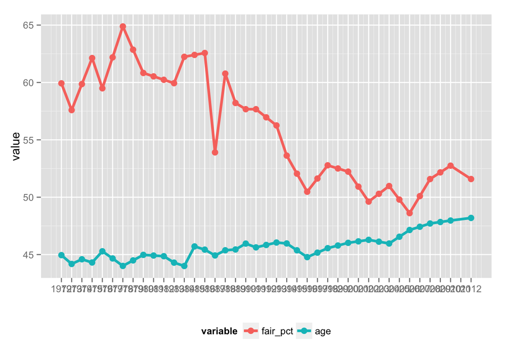

```r
(g_age <- ggMyTS(df = plot.dat, varlist = c("fair_pct", "age")))
```

#### 3. Run a simple time series regression, with one X and no trend. Interpret it.

```r
# OLS regression
lm.fair <- lm(fair_pct ~ degree_pct, data = by.year.ts)
summary(lm.fair)
```

```
##
## Call:
## lm(formula = fair_pct ~ degree_pct, data = by.year.ts)
##
## Residuals:
##     Min      1Q  Median      3Q     Max
## -4.3299 -1.5369 -0.0008  1.7317  4.8348
##
## Coefficients:
##             Estimate Std. Error t value Pr(>|t|)
## (Intercept)  72.4047     1.5338   47.21  < 2e-16 ***
## degree_pct   -0.7923     0.0721  -10.99 2.32e-13 ***
## ---
## Signif. codes:  0 '***' 0.001 '**' 0.01 '*' 0.05 '.' 0.1 ' ' 1
##
## Residual standard error: 2.394 on 38 degrees of freedom
## Multiple R-squared:  0.7607, Adjusted R-squared:  0.7544
## F-statistic: 120.8 on 1 and 38 DF,  p-value: 2.323e-13
```

Each percentage more of people with degrees decrease the belief that people would be fair to you by 0.79 percentage point on average. This is statistically significant at the 0.1% level.

```r
# test for heteroskedasticity
bptest(lm.fair)
```

```
##
##  studentized Breusch-Pagan test
##
## data:  lm.fair
## BP = 1.7841, df = 1, p-value = 0.1816
```

The null hypothesis here is that there is no heteroscedasticity. We cannot reject the null hypothesis here with a p value of 0.1816 so there is no heteroscedasticity.

#### 4. Run a time series regression with one X and trend. Interpret it. Perform autocorrelation diagnostics. Explain what you found.

```r
# include year trend
lm.fair2 <- update(lm.fair, ~ . + year)
summary(lm.fair2)
```

```
##
## Call:
## lm(formula = fair_pct ~ degree_pct + year, data = by.year.ts)
##
## Residuals:
##    Min     1Q Median     3Q    Max
## -4.545 -1.579 -0.131  1.659  4.752
##
## Coefficients:
##              Estimate Std. Error t value Pr(>|t|)
## (Intercept) 235.11304  311.55316   0.755   0.4552
## degree_pct   -0.61185    0.35316  -1.732   0.0915 .
## year         -0.08357    0.16002  -0.522   0.6046
## ---
## Signif. codes:  0 '***' 0.001 '**' 0.01 '*' 0.05 '.' 0.1 ' ' 1
##
## Residual standard error: 2.417 on 37 degrees of freedom
## Multiple R-squared:  0.7624, Adjusted R-squared:  0.7496
## F-statistic: 59.37 on 2 and 37 DF,  p-value: 2.833e-12
```

```r
vif(lm.fair2)
```

```
## degree_pct       year
##   23.53613   23.53613
```

Net of the time trend, each percentage more of people with degrees decrease the belief that people would be fair to you by 0.61 percentage point on average. This is only statistically significant at the 10% level.

There is a negative time trend here. For every one year increase, there is a 0.083 percentage point decrease on average for the belief that people would be fair to you, net of other variables.

The VIF here are both around 23 which is way higher than 10, indicating that multicollinearity is most probably present.

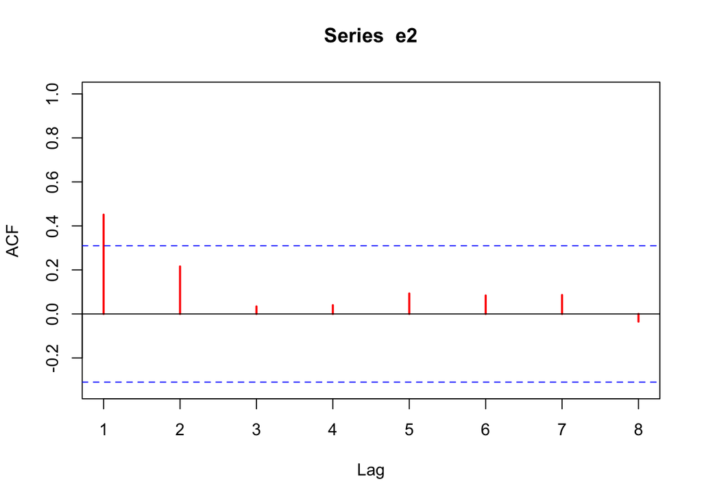

```r
#  autocorrelation test
e2 <- lm.fair2$resid
acf(e2, xlim = c(1,8), col = "red", lwd = 2)
```

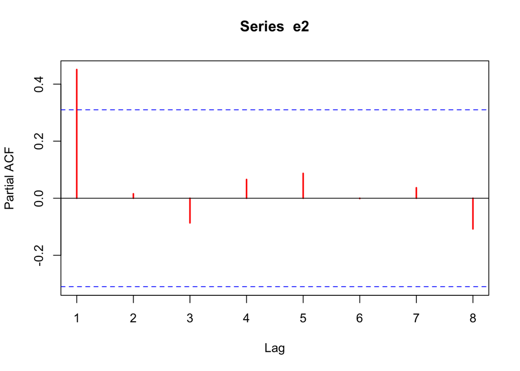

```r
pacf(e2, xlim = c(1,8), col = "red", lwd = 2)
```

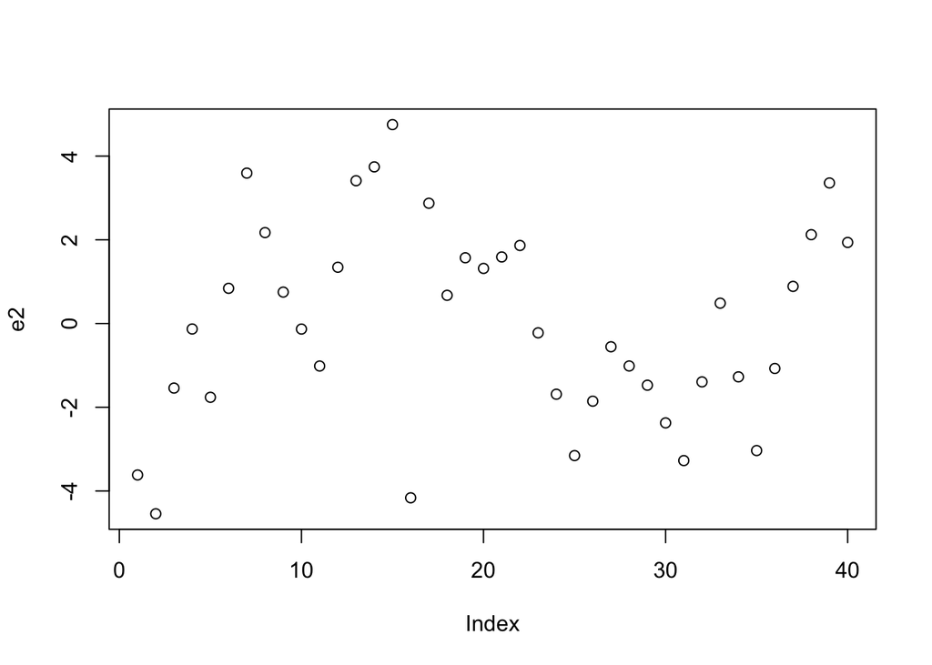

```r
plot(e2)
```

Looking at the acf it seems that there might be presence of AR(1).

```r
dwtest(lm.fair2)
```

```
##
##  Durbin-Watson test
##
## data:  lm.fair2
## DW = 1.0198, p-value = 0.0001507
## alternative hypothesis: true autocorrelation is greater than 0
```

```r
bgtest(lm.fair2)
```

```
##
##  Breusch-Godfrey test for serial correlation of order up to 1
##
## data:  lm.fair2
## LM test = 8.4011, df = 1, p-value = 0.00375
```

```r
durbinWatsonTest(lm.fair2, max.lag=3)
```

```
##  lag Autocorrelation D-W Statistic p-value
##    1      0.45113857      1.019792   0.000
##    2      0.21591255      1.342503   0.026
##    3      0.03407267      1.674331   0.348
##  Alternative hypothesis: rho[lag] != 0
```

The strongest evidence here is for AR(1).

#### 5. Consider running a time series regression with many Xs and trend. Interpret that. Check VIF.

```r
# add more predictors
lm.fair3 <- update(lm.fair2, ~ . + age + trust_pct + realrinc)
summary(lm.fair3)
```

```
##
## Call:
## lm(formula = fair_pct ~ degree_pct + year + age + trust_pct +
##     realrinc, data = by.year.ts)
##
## Residuals:
##     Min      1Q  Median      3Q     Max
## -4.3949 -1.0256 -0.3334  1.4443  4.7016
##
## Coefficients:
##               Estimate Std. Error t value Pr(>|t|)
## (Intercept)  4.718e+02  3.203e+02   1.473    0.150
## degree_pct  -3.683e-01  3.234e-01  -1.139    0.263
## year        -2.435e-01  1.704e-01  -1.429    0.163
## age          1.576e+00  6.800e-01   2.317    0.027 *
## trust_pct    2.562e-01  1.618e-01   1.584    0.123
## realrinc    -2.094e-04  1.552e-04  -1.349    0.187
## ---
## Signif. codes:  0 '***' 0.001 '**' 0.01 '*' 0.05 '.' 0.1 ' ' 1
##
## Residual standard error: 2.085 on 32 degrees of freedom
##   (2 observations deleted due to missingness)
## Multiple R-squared:  0.844,  Adjusted R-squared:  0.8197
## F-statistic: 34.64 on 5 and 32 DF,  p-value: 5.201e-12
```

According to the model above:  
Net of the time trend and other factors, each percentage more of people with degrees decrease the belief that people would be fair to you by 0.368 percentage point on average. This is not statistically significant.  
Net of the time trend and other factors, every year increase in age will increase the belief that people would be fair to you by 1.57 percentage point on average. This is statistically significant at the 5% level.  
Net of the time trend and other factors, each percentage more trusting you are increases the belief that people would be fair to you by 0.256 percentage point on average. This is not statistically significant.  
Net of the time trend and other factors, each category increase in real income will decrease the belief that people would be fair to you by 2.094 * e-04 percentage point on average. This is not statistically significant.  
Net of other factors, each additional year decrease the belief that people would be fair to you by 0.2435 percentage point on average. This is not statistically significant.

```r
vif(lm.fair3)
```

```
## degree_pct       year        age  trust_pct   realrinc
##  22.842113  30.772725   4.729803   3.539997   2.084615
```

The VIF for degree_pct (~22) and year (~30) are both above 10. While age and trust_pct are below 10 and above 2.5. Only realrinc is below 2.5. The presence of a VIF above 10 means that multicollinearity is most likely present.

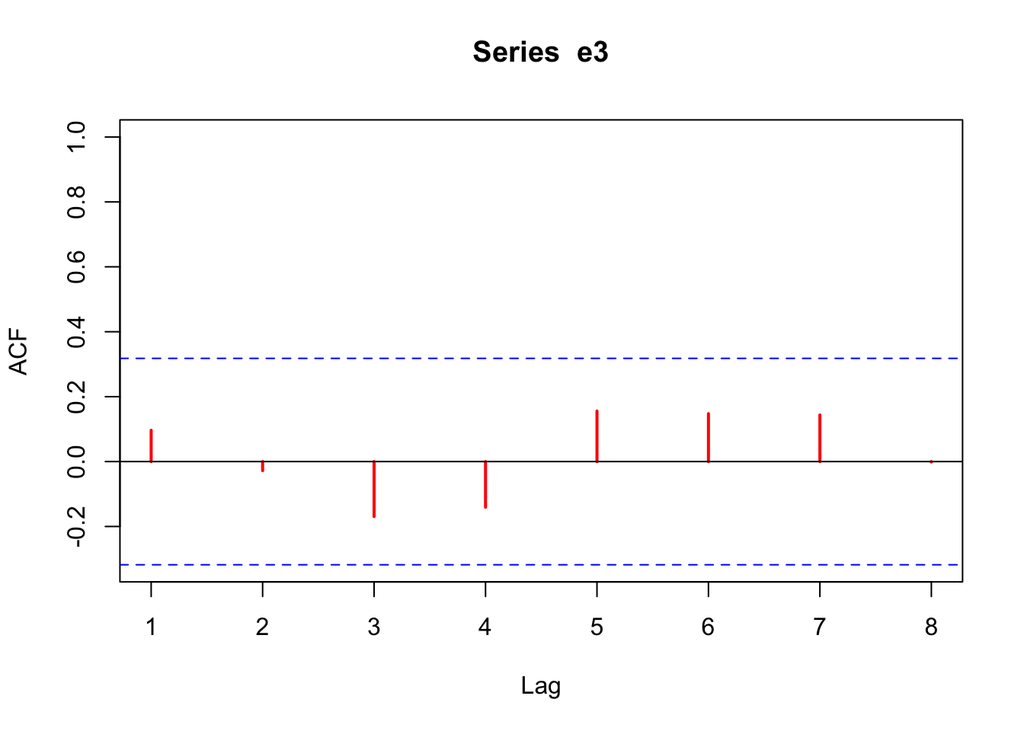

```r
e3 <- lm.fair3$resid
acf(e3, xlim = c(1,8), col = "red", lwd = 2)
```

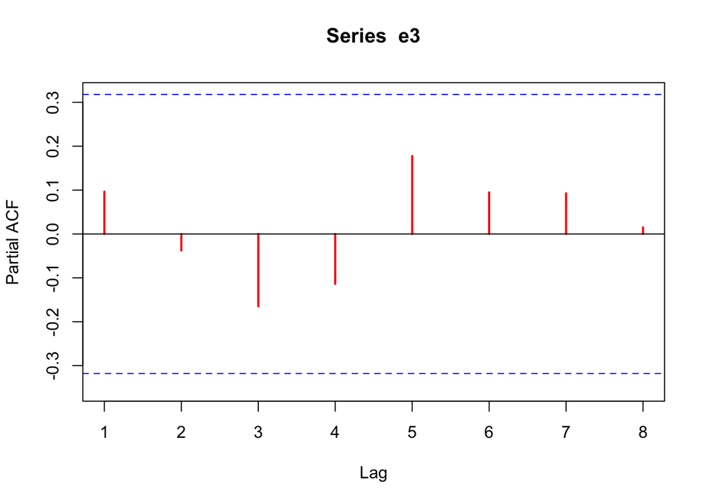

```r
pacf(e3, xlim = c(1,8), col = "red", lwd = 2)
```

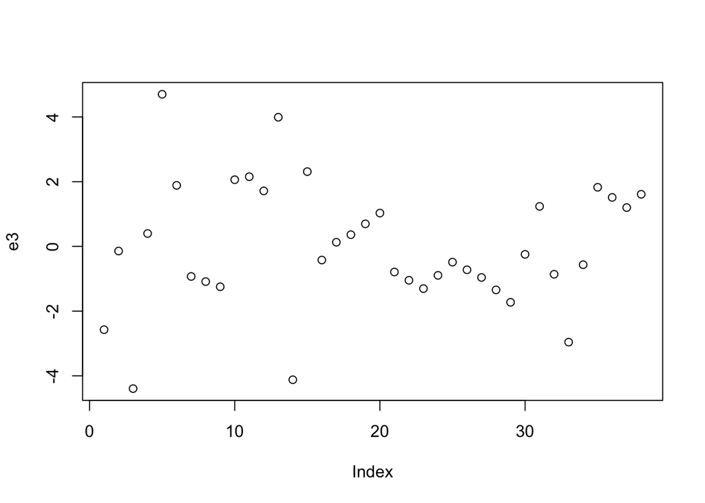

```r
plot(e3)
```

```r
# variance inflation factor
vif(lm.fair3)
```

```
## degree_pct       year        age  trust_pct   realrinc
##  22.842113  30.772725   4.729803   3.539997   2.084615
```

```r
durbinWatsonTest(lm.fair3, max.lag=2)
```

```
##  lag Autocorrelation D-W Statistic p-value
##    1      0.09650965      1.740704   0.200
##    2     -0.02799573      1.979213   0.872
##  Alternative hypothesis: rho[lag] != 0
```

#### 6. Run a first differenced time series regression. Interpret that.

```r
by.yearFD <- summarise(data.frame(by.year.ts),
                       fair_pct = firstD(fair_pct), # using firstD functon from QMSS package
                       age = firstD(age),
                       degree_pct = firstD(degree_pct),
                       trust_pct = firstD(trust_pct),
                       realrinc = firstD(realrinc),
                       year = year)
lm.fair4 <- update(lm.fair2, data = by.yearFD) # can use update to copy a model with a new dataset
summary(lm.fair4)
```

```
##
## Call:
## lm(formula = fair_pct ~ degree_pct + year, data = by.yearFD)
##
## Residuals:
##     Min      1Q  Median      3Q     Max
## -8.5720 -1.0834 -0.1308  1.2155  7.0338
##
## Coefficients:
##              Estimate Std. Error t value Pr(>|t|)
## (Intercept)  6.881273  67.902723   0.101    0.920
## degree_pct  -0.106469   0.340614  -0.313    0.756
## year        -0.003538   0.034081  -0.104    0.918
##
## Residual standard error: 2.398 on 36 degrees of freedom
##   (1 observation deleted due to missingness)
## Multiple R-squared:  0.002884,   Adjusted R-squared:  -0.05251
## F-statistic: 0.05207 on 2 and 36 DF,  p-value: 0.9493
```

From the above FD model:  
Net of the time trend, for a one percentage point difference in the percentage of people with at least bachelor degrees or above, there is a decrease of 0.106 percentage points difference of the belief that people are fair. The negative R^2 is not a good thing for the model to have since it means that our model performs worst than the baseline.

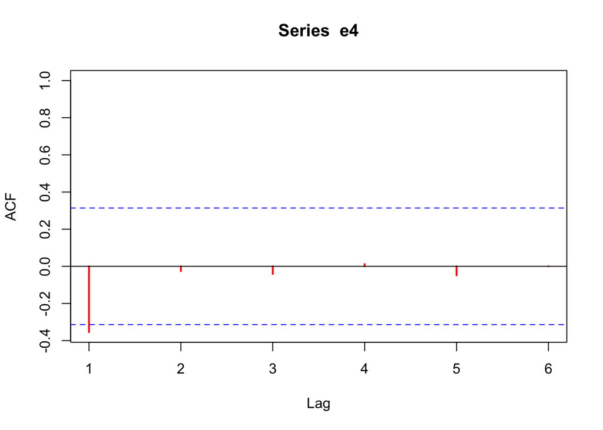

```r
e4 <- lm.fair4$resid
acf(e4, xlim = c(1,6), col = "red", lwd = 2)
```

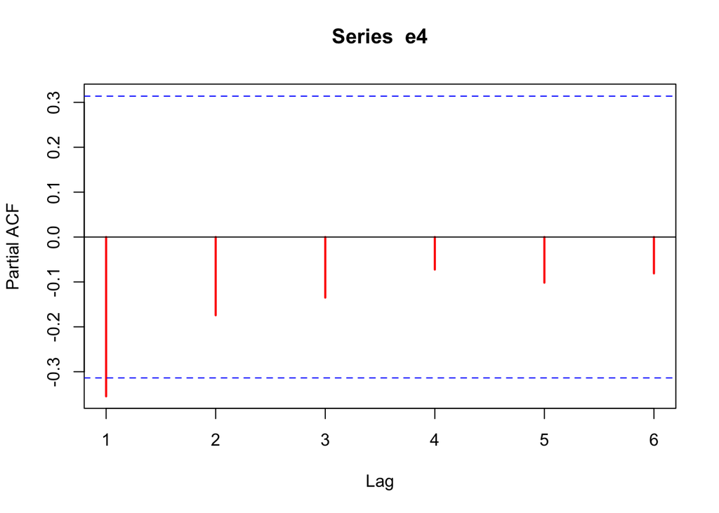

```r
pacf(e4, xlim = c(1,6), col = "red", lwd = 2)
```

#### 7. Check your variables for unit roots. Do some tests. Interpret them.

I would be running the Dickey-Fuller tests below. The null hypothesis for the DF test is that there is unit root, so ideally we would like to reject the null hypothesis.

```r
adfTest(by.year.ts[,"fair_pct"], lags = 0, type="ct")
```

```
##
## Title:
##  Augmented Dickey-Fuller Test
##
## Test Results:
##   PARAMETER:
##     Lag Order: 0
##   STATISTIC:
##     Dickey-Fuller: -3.3647
##   P VALUE:
##     0.07655
##
## Description:
##  Fri Dec 11 10:04:09 2015 by user:
```

```r
adfTest(by.year.ts[,"fair_pct"], lags = 4, type="ct")
```

```
##
## Title:
##  Augmented Dickey-Fuller Test
##
## Test Results:
##   PARAMETER:
##     Lag Order: 4
##   STATISTIC:
##     Dickey-Fuller: -2.3696
##   P VALUE:
##     0.4284
##
## Description:
##  Fri Dec 11 10:04:09 2015 by user:
```

We can see that at both lags 0 and 4, the p-values are both not smaller than 0.05 so we cannot reject the null hypothesis and so there is unit root present.

```r
# Phillips-Perron test
PP.test(by.year.ts[,"fair_pct"],lshort=TRUE)
```

```
##
##  Phillips-Perron Unit Root Test
##
## data:  by.year.ts[, "fair_pct"]
## Dickey-Fuller = -3.266, Truncation lag parameter = 3, p-value =
## 0.09117
```

This is supported also by the Phillips-Peron test with a similar null hypothesis of unit root. The p-value here is 0.09 which is larger than 0.05 and so we cannot reject the null hypothesis as well.

#### 8. Perform an Automatic ARIMA on the residuals from one of your earlier models. Tell me what it says.

```r
auto.arima(e2, trace=TRUE)
```

```
##
##  ARIMA(2,0,2) with non-zero mean : 185.1119
##  ARIMA(0,0,0) with non-zero mean : 185.3236
##  ARIMA(1,0,0) with non-zero mean : 177.9518
##  ARIMA(0,0,1) with non-zero mean : 180.4888
##  ARIMA(0,0,0) with zero mean     : 183.1046
##  ARIMA(2,0,0) with non-zero mean : 180.2688
##  ARIMA(1,0,1) with non-zero mean : 180.3133
##  ARIMA(2,0,1) with non-zero mean : 182.7128
##  ARIMA(1,0,0) with zero mean     : 175.6131
##  ARIMA(2,0,0) with zero mean     : 177.7976
##  ARIMA(1,0,1) with zero mean     : 177.8418
##  ARIMA(2,0,1) with zero mean     : 180.096
##
##  Best model: ARIMA(1,0,0) with zero mean
```

```
## Series: e2
## ARIMA(1,0,0) with zero mean
##
## Coefficients:
##          ar1
##       0.4763
## s.e.  0.1423
##
## sigma^2 estimated as 4.212:  log likelihood=-85.64
## AIC=175.29   AICc=175.61   BIC=178.67
```

```r
auto.arima(e3, trace=TRUE)
```

```
##
##  ARIMA(2,0,2) with non-zero mean : Inf
##  ARIMA(0,0,0) with non-zero mean : 161.4903
##  ARIMA(1,0,0) with non-zero mean : 163.4828
##  ARIMA(0,0,1) with non-zero mean : 163.4694
##  ARIMA(0,0,0) with zero mean     : 159.2586
##  ARIMA(1,0,1) with non-zero mean : Inf
##
##  Best model: ARIMA(0,0,0) with zero mean
```

```
## Series: e3
## ARIMA(0,0,0) with zero mean
##
## sigma^2 estimated as 3.66:  log likelihood=-78.57
## AIC=159.15   AICc=159.26   BIC=160.79
```

```r
auto.arima(e4, trace=TRUE)
```

```
##
##  ARIMA(2,0,2) with non-zero mean : 183.1649
##  ARIMA(0,0,0) with non-zero mean : 180.1034
##  ARIMA(1,0,0) with non-zero mean : 177.1989
##  ARIMA(0,0,1) with non-zero mean : 175.4171
##  ARIMA(0,0,0) with zero mean     : 177.8782
##  ARIMA(1,0,1) with non-zero mean : 177.738
##  ARIMA(0,0,2) with non-zero mean : 177.7516
##  ARIMA(1,0,2) with non-zero mean : 180.3787
##  ARIMA(0,0,1) with zero mean     : 173.0661
##  ARIMA(1,0,1) with zero mean     : 175.2485
##  ARIMA(0,0,2) with zero mean     : 175.2613
##  ARIMA(1,0,2) with zero mean     : 177.7384
##
##  Best model: ARIMA(0,0,1) with zero mean
```

```
## Series: e4
## ARIMA(0,0,1) with zero mean
##
## Coefficients:
##           ma1
##       -0.4727
## s.e.   0.1524
##
## sigma^2 estimated as 4.402:  log likelihood=-84.37
## AIC=172.73   AICc=173.07   BIC=176.06
```

Running the auto.arima function for all three models yields three different results in this case:  
For e2, we would end up with an ARIMA (1, 0, 0) model which means it is an AR(1) model.  
For e3, we would end up with an ARIMA (0, 0, 0) model which is similar to OLS.  
For 34, we would end up with an ARIMA (0, 0, 1) model which means it is an MA(1) model.

#### 9. Run an ARIMA that follows from Step 8. Interpret that, too.

```r
xvars.fat <- by.year.ts[,c("degree_pct", "year")]

# ARIMA(1,0,0)
arima.100 <- arima(by.year.ts[,"fair_pct"], order = c(1,0,0), xreg = xvars.fat)
summary(arima.100)
```

```
##
## Call:
## arima(x = by.year.ts[, "fair_pct"], order = c(1, 0, 0), xreg = xvars.fat)
##
## Coefficients:
##          ar1  intercept  degree_pct     year
##       0.5252   504.4519     -0.2494  -0.2226
## s.e.  0.1430   305.1819      0.3396   0.1565
##
## sigma^2 estimated as 4.077:  log likelihood = -85.03,  aic = 180.05
##
## Training set error measures:
##                      ME     RMSE      MAE         MPE     MAPE     MASE
## Training set 0.04802203 2.019122 1.515927 -0.05279539 2.690002 0.941456
##                     ACF1
## Training set -0.05963295
```

```r
Box.test(resid(arima.100), lag = 20, type = c("Ljung-Box"), fitdf = 0)
```

```
##
##  Box-Ljung test
##
## data:  resid(arima.100)
## X-squared = 11.845, df = 20, p-value = 0.9213
```

I have chosen to run the first ARIMA model from Step 8, which is an ARIMA (1, 0, 0) model.

Net of time trend, each percentage more people with bachelor degrees or above will decrease the belief that people are fair by 0.24 percentage points.